# Ames Housing in R

smart-R

JADS Foundation - cohort May 2023

Author

Floris Padt

Published

02-06-2023

Modified

07-06-2023

Abstract

In the Ames Housing dataset, which is commonly used for predicting housing prices, there are several  
features that can significantly influence the sales price of a house. The importance of these features  
can vary depending on the specific dataset and the machine learning algorithm used for analysis.  
However, based on general observations and common practices,  
the following features are often considered as strong predictors of housing prices:  
1. Overall Quality: The overall quality of a house, usually measured on a scale from 1 to 10, is a crucial factor affecting its sales price. Higher-quality homes tend to command higher prices.  
2. Above Ground Living Area: The size of the above ground living area, typically measured in square feet, is a strong indicator of a house’s value. Larger houses generally have higher prices.  
3. Number of Bedrooms: The number of bedrooms in a house is an important factor for many buyers. Houses with more bedrooms are typically priced higher.  
4. Number of Bathrooms: Similarly, the number of bathrooms in a house plays a significant role in determining its value. More bathrooms often lead to higher prices.  
5. Lot Size: The size of the lot on which a house is situated can influence its price. Larger lots are generally associated with higher prices, especially in desirable locations.  
6. Neighborhood: The neighborhood in which a house is located can have a significant impact on its value.

# Ames Housing in R

```r
uri <-
  'https://raw.githubusercontent.com/jads-nl/discover-projects/main/' %>%
  paste0(., 'ames-housing/AmesHousing.csv')

df =  read.csv(uri) # data.frame
dt <- fread(uri)    # data.table
```

## Introduction

The *Ames Housing* dataset contains information from the Ames Assessor’s Office used in computing assessed values for individual residential properties sold in Ames, Iowa [IA] from 2006 to 2010.  
The dataset has 2,930 observations with 82 variables. For a complete description of all included variables, please look at: https://rdrr.io/cran/AmesHousing/man/ames_raw.html.

## Exercise 1:

Familiarize yourself with the data.

Provide a table with descriptive statistics for all included variables and check:

- Classes of each of the variables (e.g. factors or continuous variables).
- Descriptive/summary statistics for all continuous variables (e.g. mean, SD, range) and factor variables (e.g. frequencies).
- Explore missing values: `sapply(df, function(x) sum(is.na(x)))`

### Data Set

```r
dt %>%
setcolorder(c("Order", "SalePrice")) %>%
DT::datatable(
  caption = "Table 1: Ames Housing dataset",
  class = "compact stripe",
  rownames = FALSE,
  filter = 'top',
  extensions = c('FixedColumns'),
  options = list(
    scrollX      = TRUE,
    fixedColumns = list(leftColumns = 2)
    )
 )  %>%
  formatCurrency("SalePrice", '\U0024', digits = 0) %>%
  formatStyle(
    'SalePrice',
    color              = "#003700",
    fontWeight         = "bold",
    backgroundColor    = '#FFFFF0',
    backgroundSize     = '100% 60%',
    backgroundRepeat   = 'no-repeat',
    backgroundPosition = 'center'
  ) %>%
  formatStyle(
    'Order',
    color              = '#C0C0C0',
    backgroundColor    = '#FFFFF0'
  )
```

| Order | SalePrice | PID | MS SubClass | MS Zoning | Lot Frontage | Lot Area | Street | Alley | Lot Shape | Land Contour | Utilities | Lot Config | Land Slope | Neighborhood | Condition 1 | Condition 2 | Bldg Type | House Style | Overall Qual | Overall Cond | Year Built | Year Remod/Add | Roof Style | Roof Matl | Exterior 1st | Exterior 2nd | Mas Vnr Type | Mas Vnr Area | Exter Qual | … |
| --- | --- | --- | --- | --- | --- | --- | --- | --- | --- | --- | --- | --- | --- | --- | --- | --- | --- | --- | --- | --- | --- | --- | --- | --- | --- | --- | --- | --- | --- | --- |
| 1 | 215000 | 526301100 | 20 | RL | 141 | 31770 | Pave |  | IR1 | Lvl | AllPub | Corner | Gtl | NAmes | Norm | Norm | 1Fam | 1Story | 6 | 5 | 1960 | 1960 | Hip | CompShg | BrkFace | Plywood | Stone | 112 | TA | … |
| 2 | 105000 | 526350040 | 20 | RH | 80 | 11622 | Pave |  | Reg | Lvl | AllPub | Inside | Gtl | NAmes | Feedr | Norm | 1Fam | 1Story | 5 | 6 | 1961 | 1961 | Gable | CompShg | VinylSd | VinylSd | None | 0 | TA | … |
| 3 | 172000 | 526351010 | 20 | RL | 81 | 14267 | Pave |  | IR1 | Lvl | AllPub | Corner | Gtl | NAmes | Norm | Norm | 1Fam | 1Story | 6 | 6 | 1958 | 1958 | Hip | CompShg | Wd Sdng | Wd Sdng | BrkFace | 108 | TA | … |
| 4 | 244000 | 526353030 | 20 | RL | 93 | 11160 | Pave |  | Reg | Lvl | AllPub | Corner | Gtl | NAmes | Norm | Norm | 1Fam | 1Story | 7 | 5 | 1968 | 1968 | Hip | CompShg | BrkFace | BrkFace | None | 0 | Gd | … |
| 5 | 189900 | 527105010 | 60 | RL | 74 | 13830 | Pave |  | IR1 | Lvl | AllPub | Inside | Gtl | Gilbert | Norm | Norm | 1Fam | 2Story | 5 | 5 | 1997 | 1998 | Gable | CompShg | VinylSd | VinylSd | None | 0 | TA | … |
| 6 | 195500 | 527105030 | 60 | RL | 78 | 9978 | Pave |  | IR1 | Lvl | AllPub | Inside | Gtl | Gilbert | Norm | Norm | 1Fam | 2Story | 6 | 6 | 1998 | 1998 | Gable | CompShg | VinylSd | VinylSd | BrkFace | 20 | TA | … |
| 7 | 213500 | 527127150 | 120 | RL | 41 | 4920 | Pave |  | Reg | Lvl | AllPub | Inside | Gtl | StoneBr | Norm | Norm | TwnhsE | 1Story | 8 | 5 | 2001 | 2001 | Gable | CompShg | CemntBd | CmentBd | None | 0 | Gd | … |
| 8 | 191500 | 527145080 | 120 | RL | 43 | 5005 | Pave |  | IR1 | HLS | AllPub | Inside | Gtl | StoneBr | Norm | Norm | TwnhsE | 1Story | 8 | 5 | 1992 | 1992 | Gable | CompShg | HdBoard | HdBoard | None | 0 | Gd | … |
| 9 | 236500 | 527146030 | 120 | RL | 39 | 5389 | Pave |  | IR1 | Lvl | AllPub | Inside | Gtl | StoneBr | Norm | Norm | TwnhsE | 1Story | 8 | 5 | 1995 | 1996 | Gable | CompShg | CemntBd | CmentBd | None | 0 | Gd | … |
| 10 | 189000 | 527162130 | 60 | RL | 60 | 7500 | Pave |  | Reg | Lvl | AllPub | Inside | Gtl | Gilbert | Norm | Norm | 1Fam | 2Story | 7 | 5 | 1999 | 1999 | Gable | CompShg | VinylSd | VinylSd | None | 0 | TA | … |

[output cut: 2920 more lines]

**Note**

- Use the base-R function `str` (no package needed)
- Use the `describe` function (from the psych-package) for continuous variables
- Use the `table` function (base-R) for factor variables.

```r
# To check the structure of the data, you can use the "str"-command:
# str(dt)

# create a table with the type of the data
dt_str <-
  dt[, lapply(.SD, typeof)]               %>%
  melt.data.table(
    measure.vars    = names(.),
    variable.factor = FALSE)              %>%
  setorder(value, variable )

# display a summery per type
dt_str %>%
  .[, .(count = .N), by = value] %>%
  DT::datatable(
    caption = "Table 2: Data structure summary",
    class = "compact stripe",
    rownames = FALSE,
    options = list(
      dom = "t"
    )
  ) %>%
  formatStyle(
    "value",
    color              = "#370037",
    backgroundColor    = "#FFFFF0",
    fontWeight         = "bold"
  )
```

| value | count |
| --- | --- |
| character | 43 |
| integer | 39 |

```r
# display structure/type of the data
dt_str %>%
  DT::datatable(
    caption = "Table 3: Data structure and types",
    class = "compact stripe",
    rownames = FALSE,
    filter = "top"
  ) %>%
    formatStyle(
      "variable",
      color              = "#370037",
      backgroundColor    = "#FFFFF0",
      fontWeight         = "bold"
    )
```

| variable | value |
| --- | --- |
| Alley | character |
| Bldg Type | character |
| Bsmt Cond | character |
| Bsmt Exposure | character |
| Bsmt Qual | character |
| BsmtFin Type 1 | character |
| BsmtFin Type 2 | character |
| Central Air | character |
| Condition 1 | character |
| Condition 2 | character |

[output cut: 72 more lines]

```r
dt_chr <- dt_str[value == "character", variable]
dt_int <- dt_str[value == "integer", variable]
```

All factor variables now have the ‘character’ class.  
The following code helps to convert each character variable into a factor variable:

```r
df[sapply(df, is.character)] <- lapply(df[sapply(df, is.character)], as.factor)
# str(df)

# convert character variables to factor variables
chr2fct <- function(x){
    if(is.character(x))
      as.factor(x)
    else
      x
  }

# convert character variables to factor variables
# keep the integers
dt[, names(dt):= lapply(.SD, chr2fct)]

# display the factors and levels
str(dt[, ..dt_chr])
```

```
Classes 'data.table' and 'data.frame':  2930 obs. of  43 variables:
 $ Alley         : Factor w/ 2 levels "Grvl","Pave": NA NA NA NA NA NA NA NA NA NA ...
 $ Bldg Type     : Factor w/ 5 levels "1Fam","2fmCon",..: 1 1 1 1 1 1 5 5 5 1 ...
 $ Bsmt Cond     : Factor w/ 6 levels "","Ex","Fa","Gd",..: 4 6 6 6 6 6 6 6 6 6 ...
 $ Bsmt Exposure : Factor w/ 5 levels "","Av","Gd","Mn",..: 3 5 5 5 5 5 4 5 5 5 ...
 $ Bsmt Qual     : Factor w/ 6 levels "","Ex","Fa","Gd",..: 6 6 6 6 4 6 4 4 4 6 ...
 $ BsmtFin Type 1: Factor w/ 7 levels "","ALQ","BLQ",..: 3 6 2 2 4 4 4 2 4 7 ...
 $ BsmtFin Type 2: Factor w/ 7 levels "","ALQ","BLQ",..: 7 5 7 7 7 7 7 7 7 7 ...
 $ Central Air   : Factor w/ 2 levels "N","Y": 2 2 2 2 2 2 2 2 2 2 ...
 $ Condition 1   : Factor w/ 9 levels "Artery","Feedr",..: 3 2 3 3 3 3 3 3 3 3 ...
 $ Condition 2   : Factor w/ 8 levels "Artery","Feedr",..: 3 3 3 3 3 3 3 3 3 3 ...
 $ Electrical    : Factor w/ 6 levels "","FuseA","FuseF",..: 6 6 6 6 6 6 6 6 6 6 ...
 $ Exter Cond    : Factor w/ 5 levels "Ex","Fa","Gd",..: 5 5 5 5 5 5 5 5 5 5 ...
 $ Exter Qual    : Factor w/ 4 levels "Ex","Fa","Gd",..: 4 4 4 3 4 4 3 3 3 4 ...
 $ Exterior 1st  : Factor w/ 16 levels "AsbShng","AsphShn",..: 4 14 15 4 14 14 6 7 6 14 ...
```

[output cut: 30 more lines]

### Explore missing values

Create a table with the number of missing values per variable.

```r
# sapply(df, function(x) sum(is.na(x)))

# table of missing values per variable
f_kbl_with_NA(dt) %>%
  kable_styling(
    full_width      = FALSE,
    position        = "left",
    htmltable_class = "lighttable-hover lighttable-condensed lightable-striped"
    )
```

| variable | value |
| --- | --- |
| Pool QC | 2917 |
| Misc Feature | 2824 |
| Alley | 2732 |
| Fence | 2358 |
| Fireplace Qu | 1422 |
| Lot Frontage | 490 |
| Garage Yr Blt | 159 |
| Garage Qual | 158 |
| Garage Cond | 158 |
| Garage Type | 157 |
| Garage Finish | 157 |
| Bsmt Qual | 79 |
| Bsmt Cond | 79 |
| Bsmt Exposure | 79 |
| BsmtFin Type 1 | 79 |
| BsmtFin Type 2 | 79 |
| Mas Vnr Area | 23 |
| Bsmt Full Bath | 2 |
| Bsmt Half Bath | 2 |
| BsmtFin SF 1 | 1 |
| BsmtFin SF 2 | 1 |
| Bsmt Unf SF | 1 |
| Total Bsmt SF | 1 |
| Garage Cars | 1 |
| Garage Area | 1 |

### Descriptive statistics

Create a table with descriptive statistics for all included variables.  
For continuous variables, you can use the `describe` function (from the psych-package).  
For factor variables, you can use the `table` function (base-R).

```r
dt[, psych::describe(.SD), .SDcols = dt_int] %>%
  as.data.table(keep.rownames = "cont_vars") %>%
  DT::datatable(
    caption  = "Table 4: Describe numerics",
    class    = "stripe",
    rownames = FALSE,
    filter   = "top",
    extensions = c('FixedColumns'),
    options = list(
      scrollX      = TRUE,
      fixedColumns = list(leftColumns = 1)
    )
  ) %>%
  formatStyle(
    "cont_vars",
    color              = "#370037",
    backgroundColor    = "#FFFFF0",
    fontWeight         = "bold"
  )
```

| cont_vars | vars | n | mean | sd | median | trimmed | mad | min | max | range | skew | kurtosis | se |
| --- | --- | --- | --- | --- | --- | --- | --- | --- | --- | --- | --- | --- | --- |
| 1st Flr SF | 1 | 2930 | 1159.55767918089 | 391.890885253492 | 1084 | 1127.16894197952 | 349.8936 | 334 | 5095 | 4761 | 1.46792444823176 | 6.94808098548229 | 7.23987974238663 |
| 2nd Flr SF | 2 | 2930 | 335.455972696246 | 428.395715008826 | 0 | 272.89590443686 | 0 | 0 | 2065 | 2065 | 0.865569795546984 | -0.417964148027411 | 7.91427812058306 |
| 3Ssn Porch | 3 | 2930 | 2.59249146757679 | 25.1413310318694 | 0 | 0 | 0 | 0 | 508 | 508 | 11.3921212784533 | 149.626587710663 | 0.464466564759549 |
| Bedroom AbvGr | 4 | 2930 | 2.8542662116041 | 0.827731141985373 | 3 | 2.83233788395904 | 0 | 0 | 8 | 8 | 0.305381285089913 | 1.88281275244272 | 0.0152916899894881 |
| Bsmt Full Bath | 5 | 2928 | 0.431352459016393 | 0.524820187946519 | 0 | 0.396331058020478 | 0 | 0 | 3 | 3 | 0.616007343592812 | -0.750298044730064 | 0.00969895615891109 |
| Bsmt Half Bath | 6 | 2928 | 0.0611338797814208 | 0.24525356625171 | 0 | 0 | 0 | 0 | 2 | 2 | 3.93675868339559 | 14.8820021753237 | 0.00453241632376827 |
| Bsmt Unf SF | 7 | 2929 | 559.26254694435 | 439.494152803924 | 466 | 510.773560767591 | 415.128 | 0 | 2336 | 2336 | 0.922107530181721 | 0.4044529561854 | 8.12069904230905 |
| BsmtFin SF 1 | 8 | 2929 | 442.629566404916 | 455.590839091153 | 370 | 384.084008528785 | 548.562 | 0 | 5644 | 5644 | 1.41473202596997 | 6.83881168009643 | 8.41812357932074 |
| BsmtFin SF 2 | 9 | 2929 | 49.722430863776 | 169.168475591582 | 0 | 2.03667377398721 | 0 | 0 | 1526 | 1526 | 4.13573910609477 | 18.7325404720877 | 3.12578965831733 |
| Enclosed Porch | 10 | 2930 | 23.0116040955631 | 64.1390592086413 | 0 | 4.82977815699659 | 0 | 0 | 1012 | 1012 | 4.01033625623208 | 28.4151135111206 | 1.18491930517856 |

[output cut: 29 more lines]

```r
my_cnt <-
  function(x){
    data.table(col = x) %>%
    .[, .(cnt = .N), by = col]
}

dt<=dtb

dt[, (names(dt)) := lapply(.SD, as.factor), .SDcols = sapply(dt, is.character)]

# Reshape the data.table into long format
cols <- sapply(dt, is.factor) %>% .[.==TRUE]
dt6  <- dt[, ..cols]

dt_long <- melt(dt6, measure.vars = names(dt6), variable.name = "Column")

# Create bar chart for each column
ggplot(dt_long, aes(x = fct_infreq(value))) +
  geom_bar() +
  facet_wrap(~Column, scales = "free_x") +
  labs(x = "Value", y = "Count") +
  theme(axis.text.x = element_text(angle = 90, hjust = 1))

tst<- lapply(dt5, my_cnt)

  dt[, .()]
  ggplot( mapping = aes(x = f, y = cnt)) +
    geom_col() +
    coord_flip() +
    facet_wrap(facets = vars(c), scales = "free")

temp <-
  df %>%
  purrr::keep(is.factor)

for (i in 1:ncol(temp)) {
  print(names(temp[i]))
  print(table(temp[, i]))
}
```

## Exercise 2:

There a several missing values in the dataset, which need to be tackled before we can proceed with the rest of the analysis.

There are many ways to impute missing values, but for now, impute missing values for numeric variables with the median, and impute missings in all factor variables with the label “100”.

### Imputation of missing values for numeric variables

```r
# impute NA with median for all numeric variables
dt[, (dt_int) := lapply(.SD, function(x){
  ifelse(is.na(x), median(x, na.rm=T), x)}), .SDcols = dt_int]

# table of missing values per variable
f_kbl_with_NA(dt)
```

| variable | value |
| --- | --- |
| Pool QC | 2917 |
| Misc Feature | 2824 |
| Alley | 2732 |
| Fence | 2358 |
| Fireplace Qu | 1422 |
| Garage Qual | 158 |
| Garage Cond | 158 |
| Garage Type | 157 |
| Garage Finish | 157 |
| Bsmt Qual | 79 |
| Bsmt Cond | 79 |
| Bsmt Exposure | 79 |
| BsmtFin Type 1 | 79 |
| BsmtFin Type 2 | 79 |

```r
df <-
  lapply(df, function(x) {
    ### Impute median for all missing numeric values
    if(is.numeric(x)) ifelse(is.na(x), median(x, na.rm=T), x) else x
  }
  ) %>%
  data.frame()
```

### Imputation of missing values for factor variables

```r
# generate a vector with variable names for all factor variables
factor_variables <-
  df              %>%
  keep(is.factor) %>%
  names

# impute missing values for factor variables
df<-
  lapply(df,function(x) {
    if(is.factor(x)) ifelse(is.na(x),"100",x) else x
  }) %>%
  data.frame()

# 100 imputation for factor variables
dt[, (dt_chr) := lapply(.SD, function(x) {
  ifelse(is.na(x), "100", as.character(x))
}), .SDcols = dt_chr]

# convert factor variables back to factor variables
# (imputation turned them into character variables)
df[factor_variables] <- lapply(df[factor_variables], factor)
dt[, (dt_chr) := lapply(.SD, as.factor), .SDcols = dt_chr]
```

### check for missing values

```r
# sapply(df, function(x) sum(is.na(x)))

# table of missing values per variable
f_kbl_with_NA(dt)
```

| variable | value |
| --- | --- |

## Exercise 3:

The variable “SalePrice” refers to the price at which a property was sold and hence is the variable of interest for our prediction model (“Y” or dependent variable).

Please explore Y in terms of:

- Descriptive/summary statistics (e.g. mean, SDs, range)
- Visualize the distribution of Y (e.g. use base-R “hist” or “ggplot” from the “ggplot2”-package)
- Visualize the distribution of Y by looking at various subgroups  
  (e.g. create boxplot or scatterplot using the “ggplot2”-package).
- Look at differences between neighborhoods.
- Look at differences between housing style.
- Draw a correlation plot to see all correlations between Y and the independent (numeric) variables.

**Note**

For visualization, ggplot is frequently used as it provides a flexible way to draw a lot of different graphs.

`ggplot` contains two basic elements:

1. The initiation command:  
   `ggplot(DATASET, aes(x=XVAR, y=YVAR, group=XVAR))`  
   This draws a blank ggplot. Even though the x and y are specified, there are no points or lines in it.
2. Add the respective geom of interest (for this exercise you’ll need:  
   `+ geom_point()` (for scatterplot) or  
   `+ geom_boxplot()`

The full code to write a scatter plot would then be:

`ggplot(DATASET, aes(x=XVAR, y=YVAR)) + geom_point()`

**Note**

To draw a correlation plot. Please use the “corrplot”-package.  
Using this package, one can construct a correlation plot in two steps:

1. Use “cor” to calculate correlation between all combinations of numeric variables  
   select numeric variables by using: `df %>% keep(is.numeric)`
2. Plot the calculated correlation by using the `corrplot` -function

### Descriptive/summary statistics

```r
# Descriptive/summary statistics (e.g. mean, SDs, range)
dt$SalePrice                   %>%
  psych::describe()            %>%
  t()                          %>%
  as.data.table(
    keep.rownames = "stat")    %>%
  .[, .(stat,
        SalesPrice = X1)]      %>%
  kbl(
    digits      = 0,
    caption     = "Table 5: Descriptive statistics for Sales Price",
    format.args = list(big.mark = ","),
    align       = 'l'
  ) %>%
  kable_styling(
    full_width      = FALSE,
    position        = "left",
    htmltable_class = "lighttable-hover lighttable-condensed lightable-striped")
```

Table 5: Descriptive statistics for Sales Price

| stat | SalesPrice |
| --- | --- |
| vars | 1 |
| n | 2,930 |
| mean | 180,796 |
| sd | 79,887 |
| median | 160,000 |
| trimmed | 170,429 |
| mad | 54,856 |
| min | 12,789 |
| max | 755,000 |
| range | 742,211 |
| skew | 2 |
| kurtosis | 5 |
| se | 1,476 |

### Visualize the distribution of Y

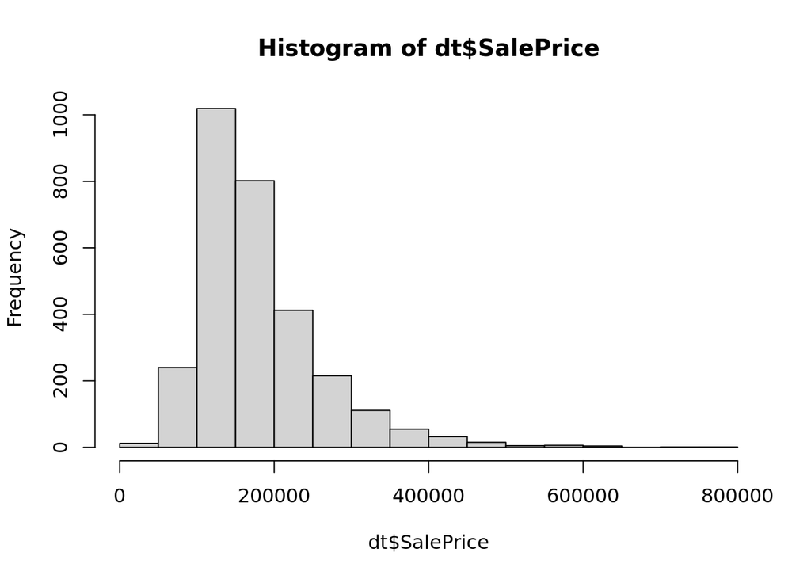

```r
# Visualize the distribution of Y
# (e.g. use base-R "hist" or "ggplot" from the "ggplot2"-package)
hist(dt$SalePrice)
```

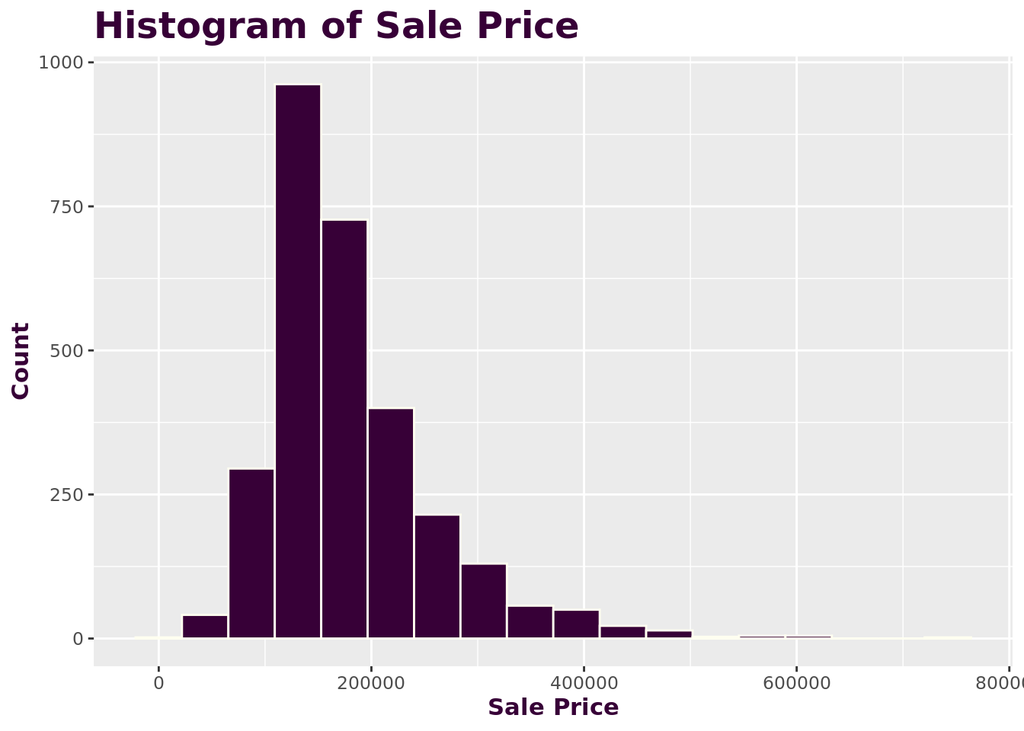

```r
ggplot(data = dt, aes(SalePrice)) +
  geom_histogram(fill = "#370037", color = "#FFFFF0", bins = 18) +
  # scale_x_continuous(limits = c(0,600000), expand = c(0, 0)) +
  # scale_y_continuous(limits = c(0,650)   , expand = c(0, 0)) +
  labs(title = "Histogram of Sale Price") +
  ylab(label = "Count") +
  xlab(label = "Sale Price") +
  # theme_classic() +
  theme(
    axis.title.x = element_text(
      colour = "#370037", size = 11.5, face = "bold"),
    axis.title.y = element_text(
      colour = "#370037", size = 11.5, face = "bold"),
    plot.title = element_text(
      colour = "#370037", size = 18  , face = "bold", hjust = 0)
  )
```

### Visualize Y by Lot Area and Neighbourhood

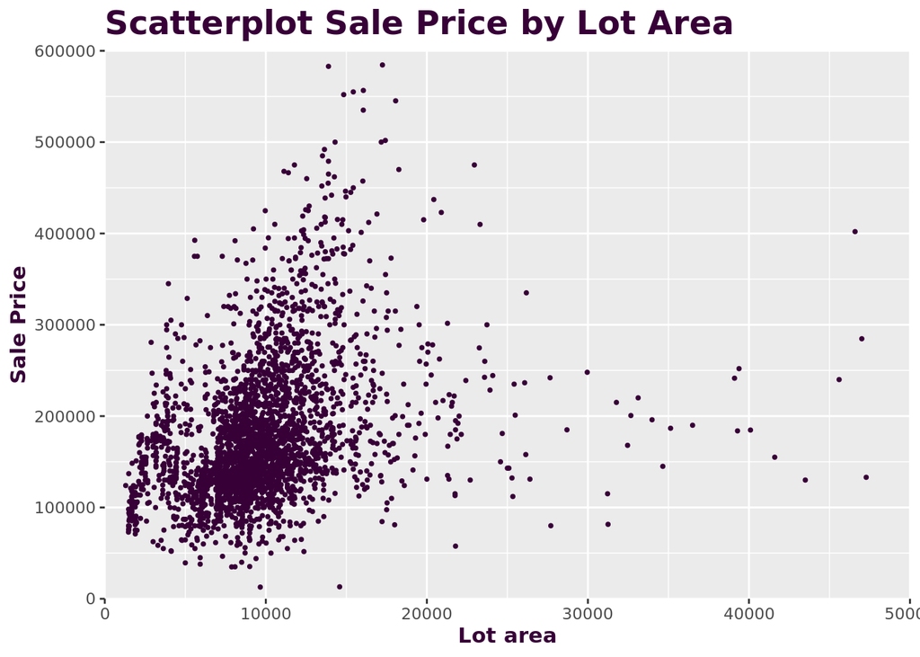

```r
# Visualize the distribution of Y by looking at various subgroups
# (e.g. create boxplot or scatterplot using the "ggplot2"-package)

# Scatterplot
ggplot(data = dt, aes(x = `Lot Area`, y = SalePrice)) +
  geom_point(size = .7, color = "#370037") +
  scale_x_continuous(limits = c(0, 50000) , expand = c(0, 0)) +
  scale_y_continuous(limits = c(0, 600000), expand = c(0, 0)) +
  labs(title = "Scatterplot Sale Price by Lot Area") +
  ylab(label = "Sale Price") +
  xlab(label = "Lot area") +
  # theme_classic() +
  theme(
    axis.title.x = element_text(
      colour = "#370037", size = 11.5, face = "bold"),
    axis.title.y = element_text(
      colour = "#370037", size = 11.5, face = "bold"),
    plot.title = element_text(
      colour = "#370037", size = 18  , face = "bold", hjust = 0))
```

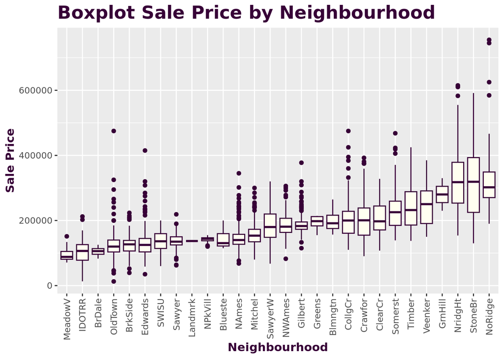

```r
# Boxplot
dt[, avgSP := mean(SalePrice), by = Neighborhood]       %>%
  .[, Neighborhood := fct_reorder(Neighborhood, avgSP)] %>%
  ggplot(aes(x = Neighborhood, y = SalePrice)) +
    geom_boxplot(color = "#370037", fill = "#FFFFF0") +
    labs(title = "Boxplot Sale Price by Neighbourhood") +
    ylab(label = "Sale Price") +
    xlab(label = "Neighbourhood") +
    # theme_classic() +
    theme(
      axis.title.x = element_text(
        colour = "#370037", size = 11.5, face = "bold"),
      axis.title.y = element_text(
        colour = "#370037", size = 11.5, face = "bold"),
      plot.title = element_text(
        colour = "#370037", size = 18  , face = "bold", hjust = 0),
      axis.text.x = element_text(angle = 90, vjust = 0.5, hjust = 1)
    )
```

### Visualize Y by House Style

**Note**

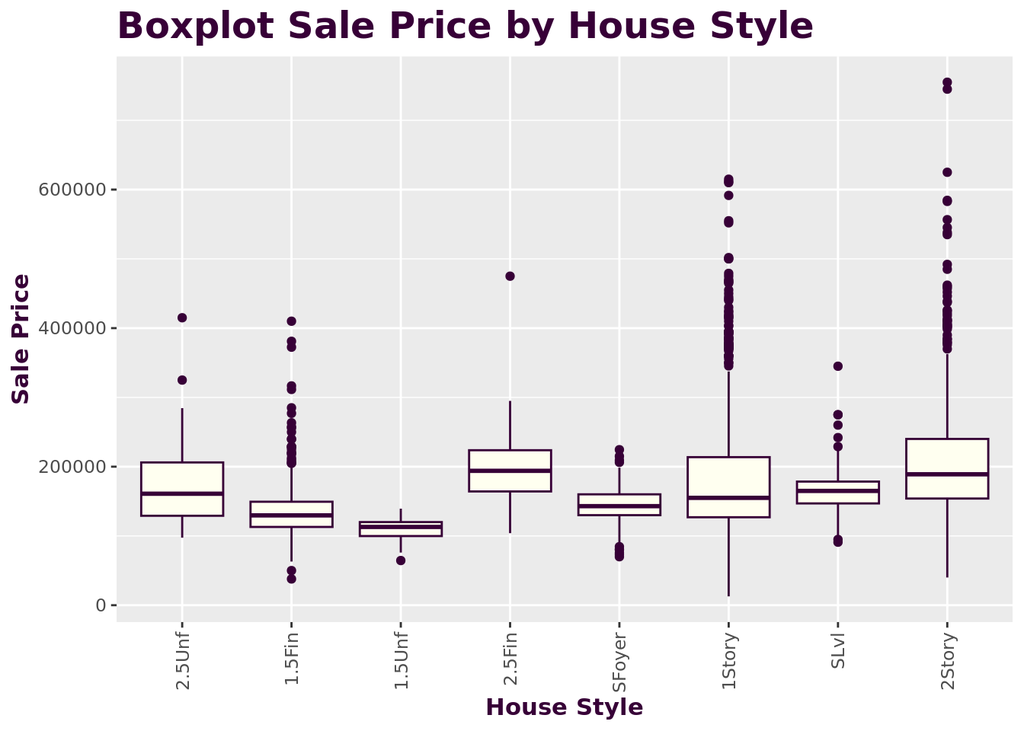

```r
#|label: Look at differences between housing style
dt[, avgHS := mean(SalePrice), by = `House Style`]        %>%
  .[, `House Style` := fct_reorder(`House Style`, avgSP)] %>%
  ggplot(aes(x = `House Style`, y = SalePrice)) +
    geom_boxplot(color = "#370037", fill = "#FFFFF0") +
    labs(title = "Boxplot Sale Price by House Style") +
    ylab(label = "Sale Price") +
    xlab(label = "House Style") +
    # theme_classic() +
    theme(
      axis.title.x = element_text(
        colour = "#370037", size = 11.5, face = "bold"),
      axis.title.y = element_text(
        colour = "#370037", size = 11.5, face = "bold"),
      plot.title = element_text(
        colour = "#370037", size = 18  , face = "bold", hjust = 0),
      axis.text.x = element_text(angle = 90, vjust = 0.5, hjust = 1))
```